# Generating Transition Densities of Generalized Quadratic Diffusion Processes

Etienne A.D. Pienaar

August, 2016

# Cumulant truncation procedure

DiffusionRgqd approximates the solution to the Kolmogorov forward eqn
$$\frac{\partial}{\partial t} f(X_t|X_s) = -\frac{\partial}{\partial X_t} [\mu(X_t,t) f(X_t|X_s)]+\frac{1}{2}\frac{\partial^2}{\partial X_t^2} [\sigma^2(X_t,t) f(X_t|X_s)],$$
by calculating the conditional moment trajectories of a diffusion process over time and subsequently carrying these moments into a suitable surrogate density. For example, given a scalar generalized quadratic diffusion:

$$dX_t = (G_0(t)+G_1(t)X_t+G_2(t)X_t^2)dt +\sqrt{Q_0(t)+Q_1(t)X_t+Q_2(t)X_t^2}dB_t,$$

it is possible to derive a system of differential equations that govern the evolution of the cumulants of the process over time. Let $\kappa_i(t)$ denote the $i$-th cumulant of $X_t$ given that the process assumes the initial value $X_s$, then:
$$\begin{aligned}
\frac{\partial}{\partial t}{\kappa}_j(t)=&G_0(t)\mbox{Ind}(j = 1)\\
&+G_1(t) j\kappa_{j}(t)\\
&+G_2(t)\biggl(j\kappa_{j+1}(t)+\sum_{r=1}^{j}r{j\choose r}\kappa_{r}(t)\kappa_{j-r+1}(t)\biggr)\\
&+Q_0(t)\mbox{Ind}(j = 2)\\
&+Q_1(t)\frac{j(j-1)}{2}\kappa_{j-1}(t)\mbox{Ind}(j \geq 2)\\
&+Q_2(t)\biggl(\frac{j(j-1)}{2}\kappa_j(t)+\frac{j}{2}\sum_{r=1}^{j-1}r {j-1\choose r} \kappa_{r}(t)\kappa_{j-1-r+1}(t)\biggr)\mbox{Ind}(j \geq 2),\\
\end{aligned}$$
for $i = 1,2,\ldots$. By solving these equations numerically using high order [Runge-Kutta](https://en.wikipedia.org/wiki/Runge-Kutta_methods) methods, we may plug the resulting moment trajectories into a suitable surrogate density such as a Normal distribution or a saddlepoint approximation in order to approximate the transitional density.

# Generate the transition density of a time-inhomogeneous GQD

As an introductory example to the **DiffusionRgqd** package we approximate the transitional density of a scalar diffusion over an arbitrarily chosen transition horizon. This can be achieved using the `GQD.density()` function. `GQD.density()` generates the transitional density of a GQD for a given initial value using the cumulant truncation procedure developed by (Varughese 2013). The function serves as a good starting point for any analysis being conducted using the **DiffusionRgqd** package as it allows one to check whether a proposed model does not exhibit nonsensical dynamics with respect to the problem at hand. Perhaps more importantly, it can be used to check the validity of the density approximation and/or an appropriate truncation order used for the cumulants.

Consider a [Cox-Ingersoll-Ross (CIR)](https://en.wikipedia.org/wiki/Cox-Ingersoll-Ross_model) (Cox, Ingersoll Jr, and Ross 1985) process with time-dependent coefficients:

$$dX_t = 2(10+\sin(2\pi (t-0.5))-X_t)dt+\sqrt{0.25(1+0.75\sin(4 \pi t))X_t}dB_t.$$

In order to analyse this SDE in **R** we need to define the model within the workspace. Since **DiffusionRgqd** uses a functional input interface (see the introductory vignette) which relies on declaring the functional form of a given model’s coefficients, we need to make sure that the workspace doesn’t contain any object names that might clash with those of the model coefficients. We can do this by simply running the `GQD.remove()` command:

```r
 library(DiffusionRgqd)
 GQD.remove()
```

```
## [1] "Removed :  NA "
```

If any objects are recognized with names that may clash with names reserved for use with the {GQD.density()} function they will subsequently be removed. In this case we used a *vanilla* **{R}** session so the function will simply indicate that no clashes were detected and removed. The purpose of the {GQD.remove()} function is to act as a *model-eraser* in situations where multiple models are being defined in a single **R** session. The next step is to write the SDE in terms of its coefficients. We can define the SDE in the current **R** session by declaring the coefficient functions:

```r
 G0 <- function(t){2*(10+sin(2*pi*(t-0.5)))}
 G1 <- function(t){-2}
 Q1 <- function(t){0.25*(1+0.75*(sin(4*pi*t)))}
```

The functions {G0}, {G1} and {Q1} together constitute the **R**-language counterpart of the SDE under the generalized quadratic framework. Note that for scalar GQDs we have capitalized the coefficient names in order to avoid the possibility of calling {q()} accidentally, in which case the **R** console will prompt to quit.

In order to approximate the transitional density using the cumulant truncation procedure we need to define the peripheral parameters of the problem. This consists of giving the initial condition of the SDE (the starting value of the diffusion), the starting time of the diffusion and the geometry of the transitional horizon, i.e. spatial values where the density is to be evaluated and the corresponding time mesh. These elements can be defined by assigning values to the arguments of `GQD.density()`: `Xs`, `Xt`, `s`, `t` and `delt`. Respectively, these parameters represent the initial value, the values at which to evaluate the transition density, the starting time, the final time and the step size for the time mesh. That is, for a diffusion process starting at time `s` in state `Xs`, the transition density is approximated at times `s+delt`, `s+2*delt` … up to and including `t` at all values of the vector `Xt`. In **R**:

```r
 states    <- seq(5, 15, 1/10)
 initial   <- 8
 Tmax      <- 5
 Tstart    <- 1
 increment <- 1/100

 M <- GQD.density(Xs = initial, Xt = states, s = Tstart, t = Tmax, delt = increment)
```

```
##
##  ================================================================
##                   Generalized Quadratic Diffusion (GQD)
##  ================================================================
##  _____________________ Drift Coefficients _______________________
##  G0 : 2*(10+sin(2*pi*(t-0.5)))
##  G1 : -2
##  G2
##  ___________________ Diffusion Coefficients _____________________
##  Q0
##  Q1 : 0.25*(1+0.75*(sin(4*pi*t)))
##  Q2
##  __________________ Distribution Approximant ____________________
##  Density approx. : Saddlepoint
##  P               :
##  alpha           :
##  Trunc. Order    : 4
##  Dens.  Order    : 4
## =================================================================
```

`GQD.density()` creates a list containing a matrix of density values, spatial coordinates at which the density was evaluated, corresponding time coordinates for the time mesh and finally a matrix of trajectories for the cumulants and moments that were used in evaluating the density approximation. In this case we have assigned the output to an object called `M` for further use in the workspace. Since the density approximation is evaluated over a space-time lattice it can best be visualized with a perspective plot:

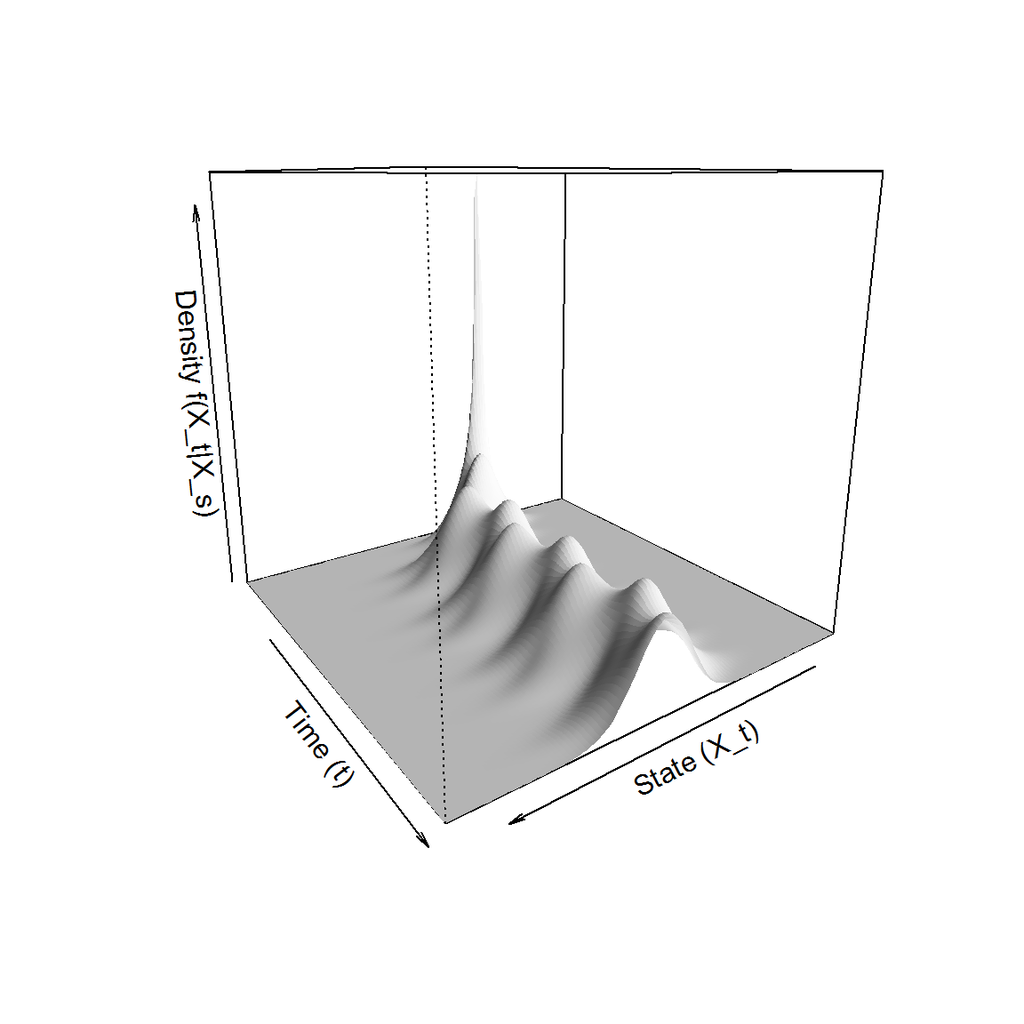

```r
persp(x = M$Xt, y = M$time, z = M$density, col = 'white', xlab = 'State (X_t)', ylab = 'Time (t)',
      zlab = 'Density f(X_t|X_s)', border = NA, shade = 0.5, theta = 145)
```

Alternatively, one can simply use `GQD.plot(M)` in order to visualize a given density approximation in a similar way.

Note that we have not directly specified what truncation order to be used in the calculation of the density approximation. The default is to use a 4-th order truncation in conjunction with a 4-th order truncated saddlepoint approximation. In most cases it suffices to use the default settings although, as will be shown in the following example, little effort is required to extend the analysis to higher order truncations and/or alternate density approximations. Although this example operates well within the limits of the capabilities of the methodology it serves to illustrate the simplicity of the interface of the **DiffusionRgqd** package - often producing desired results in less than 10 lines of code with minimal mathematical input.

# Time-inhomogeneous Jacobi diffusion: A scalar diffusion with finite support

```r
# Set some parameter values:
a <- 0.5; b <- 0.6; cc <- 1; X0 <- 0.5;

# Give the coefficient form of the diffusion.:
G0 <- function(t){a*(b*(1 + 0.25*sin(pi*t)))}
G1 <- function(t){-a}
Q1 <- function(t){cc}
Q2 <- function(t){-cc}
# What states should the density be evaluated at:
states=seq(1/1000,1-1/1000,1/1000)

# Generate the transitional density for truncation orders 4,6 and 8:
res1 <- GQD.density(X0, states, 0, 2, 0.01, Dtype = 'Beta', Trunc = c(4,4))
```

```
##
##  ================================================================
##                   Generalized Quadratic Diffusion (GQD)
##  ================================================================
##  _____________________ Drift Coefficients _______________________
##  G0 : a*(b*(1+0.25*sin(pi*t)))
##  G1 : -a
##  G2
##  ___________________ Diffusion Coefficients _____________________
##  Q0
##  Q1 : cc
##  Q2 : -cc
##  __________________ Distribution Approximant ____________________
##  Density approx. : Beta
##  P               : 100
##  alpha           : 0
##  Trunc. Order    : 4
##  Dens.  Order    : 4
## =================================================================
```

```r
res2 <- GQD.density(X0, states, 0, 2, 0.01, Dtype = 'Beta', Trunc = c(6,6), print.output = FALSE)
res3 <- GQD.density(X0, states, 0, 2, 0.01, Dtype = 'Beta', Trunc = c(8,8), print.output = FALSE)
```

The objects `res1`, `res2` and `res3` now contain the transitional density approximations for truncation order 4, 6 and 8. The additional parameter `Dtype = 'Beta'` sets the density approximation to the multi-modal Beta class developed by Cobb, Koppstein, and Chen (1983). That is, let:
$$\mathbf{A} =
\begin{pmatrix}
1&u_1(t)&\ldots&u_{m/2}(t)\\
u_1(t)&u_2(t)&\ldots& u_{m/2+1}(t)\\
\vdots&\vdots&\ddots&\vdots\\
u_{m/2}(t)&u_{m/2+1}(t)&\ldots&u_{m}(t)\\
\end{pmatrix},$$
and $\boldsymbol{\beta}=\{\beta_1,\beta_2,\ldots,\beta_{m/2+1}\}$. Then the multi-modal Beta distribution of order $m$ is given by:
$$\tilde{f}_B^{(m)}(x|X_s) \propto x^{-\beta_1} (1-x)^{-\sum_{i=1}^{m/2+1}\beta_i}\exp\biggl(-\sum_{i=1}^{m/2-1}\bigl(\sum_{j=i+1}^{m/2}\beta_j\bigr)x^{i}/i\biggr) \quad \forall x \in [0,1],$$
where $\boldsymbol{\beta} = \mathbf{A}\mathbf{v}$ and $\mathbf{v}=\{v_i=iu_{i-1}(t)-(i+1)u_{i}(t):i=1,...,m/2+1\}^{\prime}$. while the variable `Trunc = c(6,6)` sets the cumulant truncation (first item in `c(6,6)`) to $m=6$ (thus evaluating the cumulant equations for all orders $i = 1, 2, \ldots, 6$) whilst setting $m=6$ for the density approximation (second item in `c(6,6)`). Note that we separate the cumulant truncation order from that of the density in order to allow lower order density truncations under a given cumulant truncation order, for example `Trunc=c(6,4)`.

In order to check the accuracy of the approximation we may compare the approximate transition density to a simulated transition density of the Jacobi diffusion. This can be achieved by simulating a number of sample paths for the Jacobi diffusion and subsequently plotting a histogram of the resulting trajectories. For a diffusion process with SDE:
$$dX_t=\mu(X_t,t)dt+\sigma(X_t,t)dB_t$$
we may simulate a trajectory at discrete time points by applying a Euler-Maruyama scheme to the Jacobi diffusion and evaluate the resulting difference equation iteratively. That is given an initial value $X_{t_0}$, we evaluate for all $i=1,2,\ldots$:
$$X_{t_i}=X_{t_{i-1}}+\mu(X_{t_{i-1}},t_{i-1})\Delta+\sigma(X_{t_{i-1}},t_{i-1}) r_{\Delta}$$
where $r_{\Delta}\sim \mbox{N}(0,\sigma^2=\Delta)$ and $t_i-t_{i-1}=\Delta$. By plugging the drift and diffusion terms of the Jacobi diffusion into this updating equation we may simulate a number of trajectories for the restricted diffusion. However, since the Euler scheme is not exact the simulated paths may actually exit the $[0,1]$ region. As such we employ the simple modification that at each iteration $X_{t_i}$ is set to $\min(\max(0,X_{t_{i-1}}+\mu(X_{t_{i-1}},t_{i-1})\Delta+\sigma(X_{t_{i-1}},t_{i-1}) r_{\Delta}),1)$. By simulating a large number of trajectories we can compare each respective density approximation by superimposing the approximation over a histogram of the simulated trajectories at any given time point. This can easily be achieved using the code:

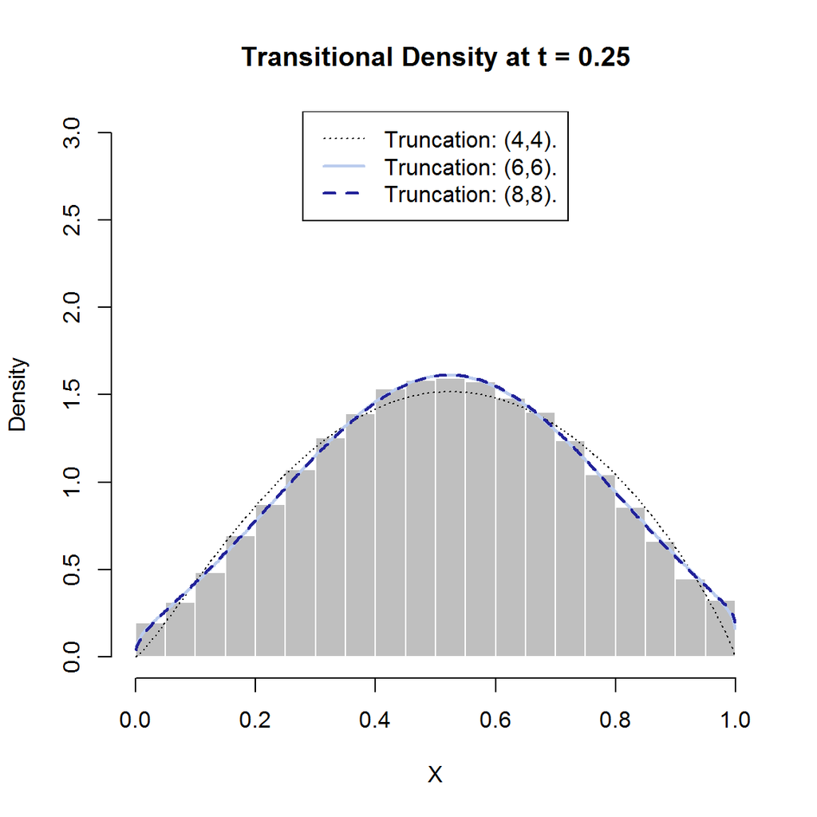

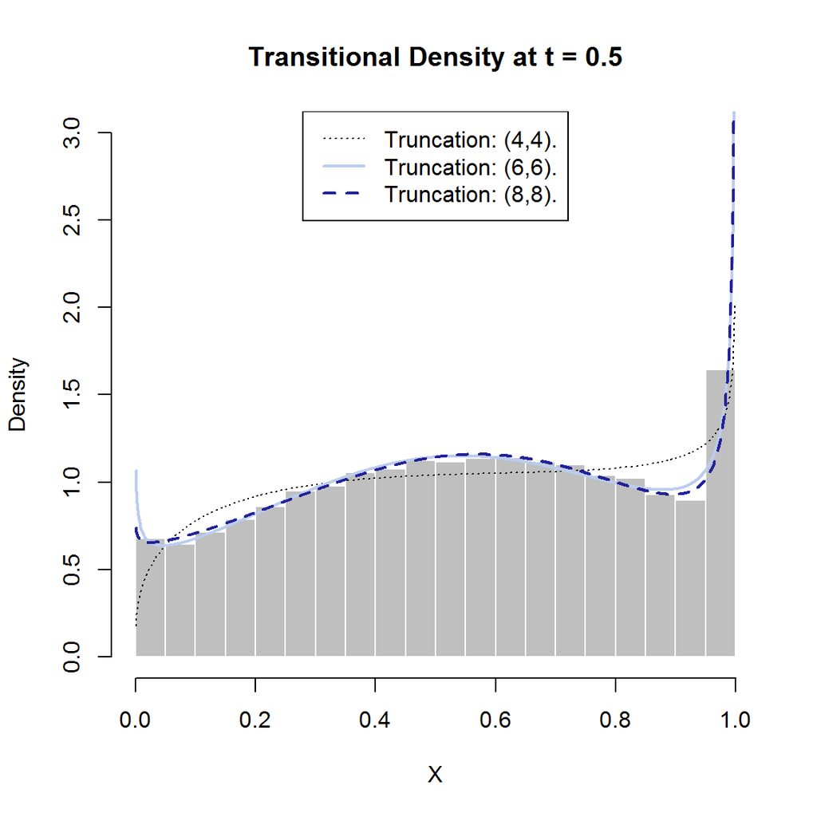

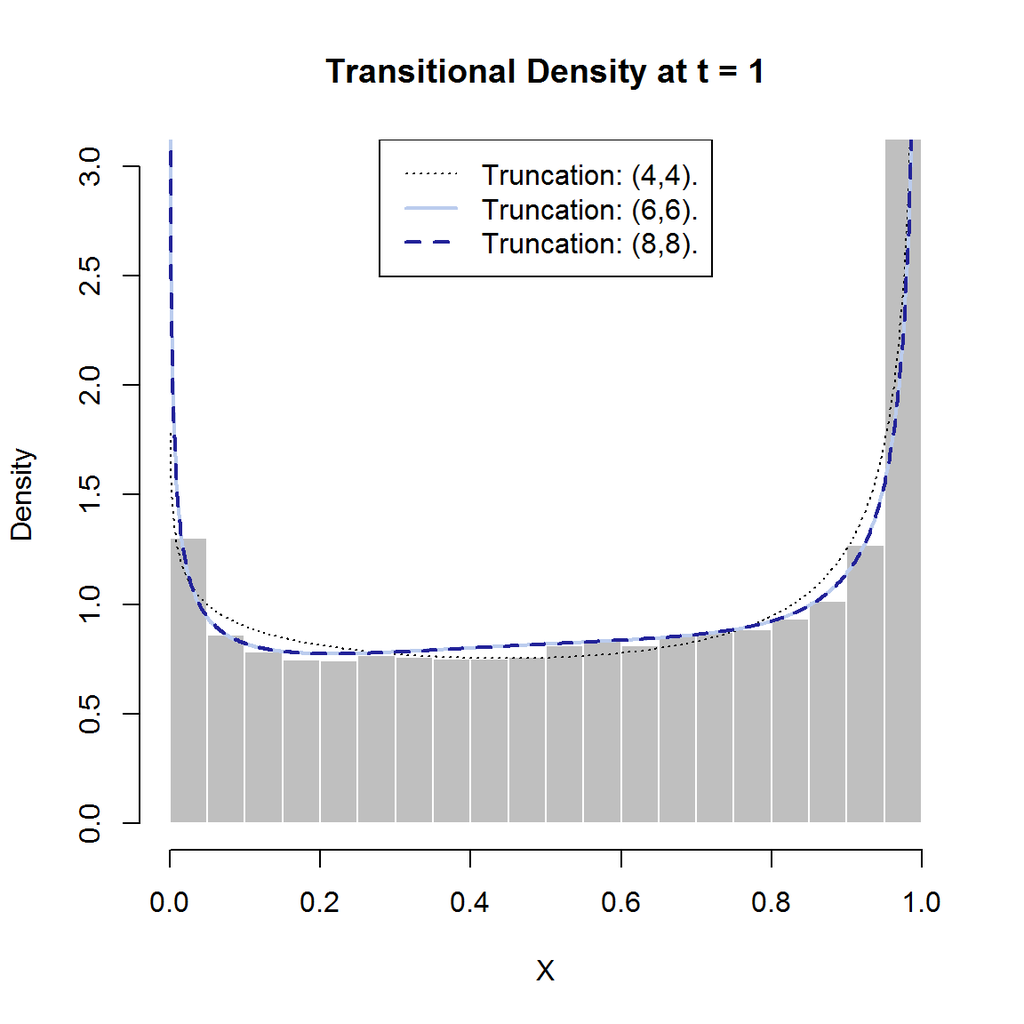

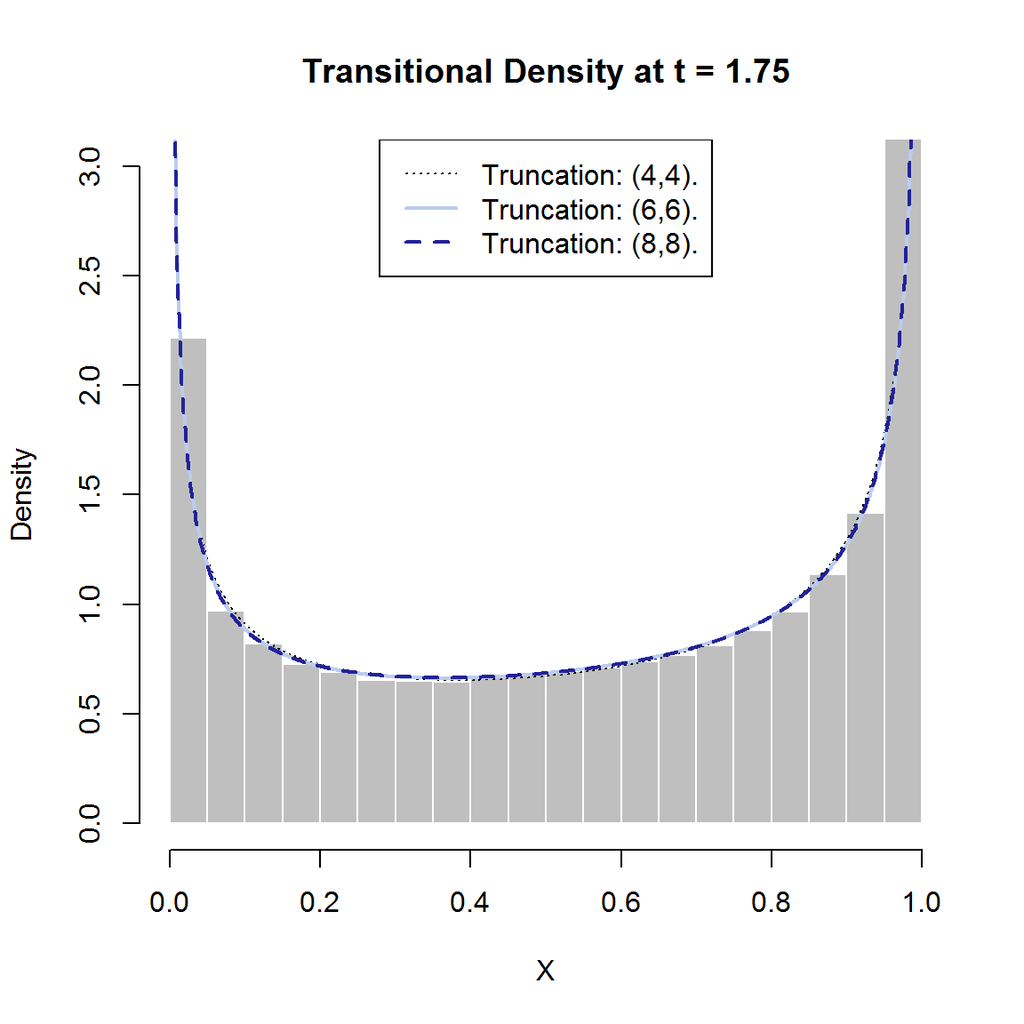

```r
N <- 100000      # Number of trajectories to simulate.
smdelt <- 1/1000 # Simulation stepsize.
d <- 0           # A variable for tracking time.
X <- rep(X0,N)
# Take snapshots of the density at these times:
when <- c(0,0.25,0.5,1,1.75)
for(i in 2:(2/smdelt))
{
# A Euler-Maruyama type approximation:
X <- pmax(pmin(X + (G0(d)+G1(d)*X)*smdelt+sqrt(Q1(d)*X+Q2(d)*X^2)*rnorm(length(X),sd=sqrt(smdelt)),1),0)
d <- d+smdelt
if(any(when==round(d,3)))
{
index <- which(res1$time==round(d,3))
hist(X, col='grey75', freq = FALSE, breaks = 30, ylim = c(0,3), border = 'white',
     main = paste0('Transitional Density at t = ',round(d,3)))
lines(res1$density[,index]~res1$Xt, col = 'black'  , lty = 'dotted',lwd = 1)
lines(res2$density[,index]~res2$Xt, col = '#BBCCEE', lty = 'solid' ,lwd = 2)
lines(res3$density[,index]~res3$Xt, col = '#222299', lty = 'dashed',lwd = 2)
legend('top', legend=c('Truncation: (4,4).','Truncation: (6,6).',
'Truncation: (8,8).'), col = c('black','#BBCCEE','#222299'),
lty=c('dotted', 'solid', 'dashed'),lwd =c(1, 2, 2),bg='white')
}
}
```

The resulting figures suggest that the approximation remains accurate for truncation orders $6$ and $8$ whilst $m=4$ produces less desirable results. Interestingly, as time progresses it seems that all orders of approximation produce a reasonable approximation of the transition density. This may be due to the long-run dynamics of the process being somewhat simpler than in early phases in the transition horizon.

Using the `persp()` function we can again generate a perspective plot of the transition density in order to get an overall view of the transitional density. Using the $m=6$-th order truncation:

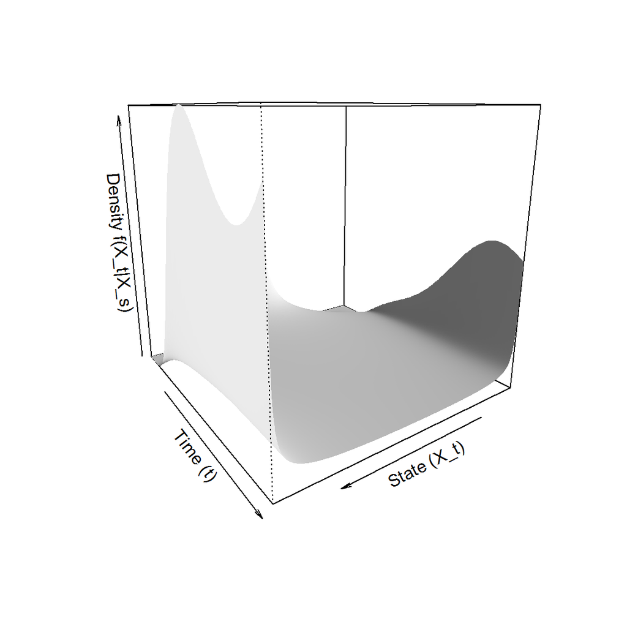

```r
persp(x = res2$Xt, y = res2$time, z = res2$density, col = 'white', xlab = 'State (X_t)', ylab = 'Time (t)',
      zlab = 'Density f(X_t|X_s)', border = NA, shade = 0.5, theta = 145)
```

As in the previous example this can be done by using the `GQD.plot()` command i.e., `GQD.plot(res3)`. As is typical for diffusion processes we see that the transitional density starts out as an infinite point mass and shortly exhibits a normal-like distribution. As time progresses, however, the density transits into a `U-shape’ with oscillating peakedness in conjunction with the sinusoidal term of the drift function.

Although the **DiffusionRgqd** package allows one to perform comprehensive analysis on scalar quadratic diffusions, similar analysis can be conducted for interesting bivariate diffusions. Under the generalized quadratic framework the corresponding template stochastic differential equation is given by the system:

$$d\mathbf{X}_t =\boldsymbol\mu(\mathbf{X}_t,t)dt+\boldsymbol\sigma(\mathbf{X}_t,t)d\mathbf{B}_t$$
where

$$\boldsymbol\mu(\mathbf{X}_t,t)=
\begin{bmatrix}
\sum_{i+j\leq 2}a_{ij}(t)X_t^iY_t^j\\
\sum_{i+j\leq 2}b_{ij}(t)X_t^iY_t^j\\
\end{bmatrix}$$

and

$$\boldsymbol\sigma(\mathbf{X}_t,t)\boldsymbol\sigma^{\prime}(\mathbf{X}_t,t) =
\begin{bmatrix}
\sum_{i+j\leq 2}c_{ij}(t)X_t^iY_t^j&\sum_{i+j\leq 2}d_{ij}(t)X_t^iY_t^j\\
\sum_{i+j\leq 2}e_{ij}(t)X_t^iY_t^j&\sum_{i+j\leq 2}f_{ij}(t)X_t^iY_t^j\\
\end{bmatrix}.$$

A model that is often used to illustrate non-linear dynamics in the analysis of ordinary differential equations is that of the Lotka-Volterra model. The corresponding ODEs are typically given as:
$$\begin{aligned}
\frac{\partial x_t}{\partial t} &= a x_t-bx_t y_t\\
\frac{\partial y_t }{\partial t} &= -c y_t+dx_t y_t\\
\end{aligned}$$
for some positive $a$, $b$, $c$ and $d$. The equations are often used to describe the dynamics of two interacting populations wherein the population growth rate of the populations are mutually influenced by the current level of the opposing population. As such the model has been used to explain oscillatory behaviour in predator-prey relationships {Hoppensteadt2006} where $x_t$ denotes the prey population and $y_t$ the predator population at time $t$. Continuing with the predator-prey metaphor, perhaps one deficiency of the model, one might argue, is the absence of random input and subsequent effects on population levels. Indeed, under the ODE formulation the predicted population behaviour (given fixed parameters) are completely deterministic. Another deficiency might be the absence of growth inhibiting factors such as disease or over-grazing. For these purposes we may define an example of a stochastic counterpart to the Lotka-Volterra equations as:
$$\begin{aligned}
dX_t &=( a X_t-bX_t Y_t)dt+f\sqrt{X_t}dB_t^{(1)}\\
dY_t &=(-c Y_t+dX_t Y_t-eY_t^2)dt+g\sqrt{Y_t}dB_t^{(2)}\\
\end{aligned}$$
The intuition behind the example diffusion is that the drift terms replicate the deterministic Lotka-Volterra eqns but with the addition of the $-eY_t^2$ term. The additional term represents the effect of overpopulation for the predator when, for example, harvesting of prey becomes ever more inefficient as the predator population grows. Furthermore, the population volatilities are assumed to increase with population size meaning that random fluctuations are less severe when populations are small and *vice versa*.

In order to analyse the stochastic Lotka-Volterra eqns, we may consider the evolution of its transitional density. This can be achieved in similar fashion to the previous examples through the `BiGQD.density()` function (the prefix `Bi’ indicating that we are working with a bivariate process). For purposes of this example, consider the SDE:
$$\begin{aligned}
dX_t &=( 1.5X_t-0.4X_t Y_t)dt+\sqrt{0.05X_t}dB_t^{(1)}\\
dY_t &=(-1.5Y_t+0.4dX_t Y_t-0.2Y_t^2)dt+\sqrt{0.1Y_t}dB_t^{(2)}\\
\end{aligned}$$
with initial values $X_0=5$ and $Y_0=5$. In **R** we may generate the transitional density over the transition horizon $t\in [0,10]$ using the code:

```r
library(DiffusionRgqd)
# Remove any existing coefficients:
GQD.remove()
```

```
## [1] "Removed :  G0 G1 Q1 Q2"
```

```r
# Define the X dimesnion coefficients:
a10 <- function(t){1.5}
a11 <- function(t){-0.4}
c10 <- function(t){0.05}
# Define the Y dimension coefficients:
b01 <- function(t){-1.5}
b11 <- function(t){0.4}
b02 <- function(t){-0.2}
f01 <- function(t){0.1}
# Approximate the transition density
res <- BiGQD.density(Xs = 5, Ys = 5, Xt = seq(3, 8, length = 50), Yt = seq(2, 6, length = 50),
                     s = 0, t = 10, delt = 1/100)
```

```
##
##  ================================================================
##                    GENERALIZED QUADRATIC DIFFUSON
##  ================================================================
##  _____________________ Drift Coefficients _______________________
##  a10 : 1.5
##  a11 : -0.4
##  ...   ...   ...   ...   ...   ...   ...   ...   ...   ...   ...
##  b01 : -1.5
##  b02 : -0.2
##  b11 : 0.4
##  ___________________ Diffusion Coefficients _____________________
##  c10 : 0.05
##  ...   ...   ...   ...   ...   ...   ...   ...   ...   ...   ...
##  ...   ...   ...   ...   ...   ...   ...   ...   ...   ...   ...
##  ...   ...   ...   ...   ...   ...   ...   ...   ...   ...   ...
##  f01 : 0.1
## =================================================================
```

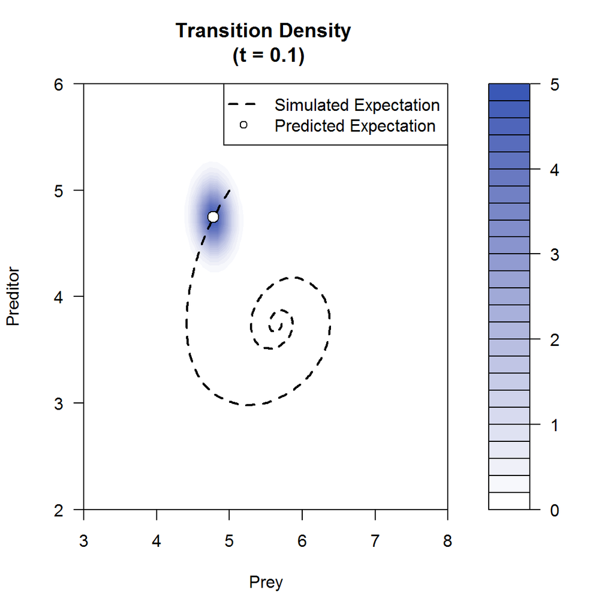

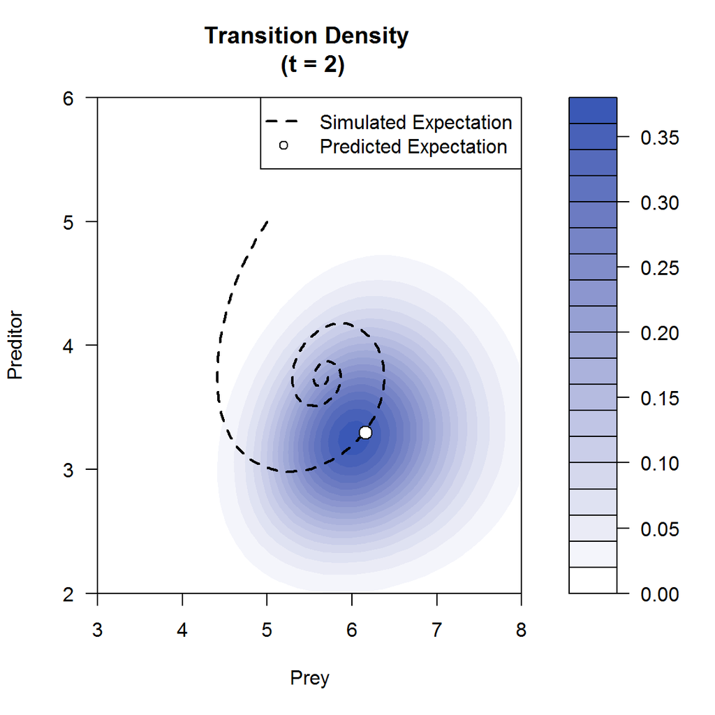

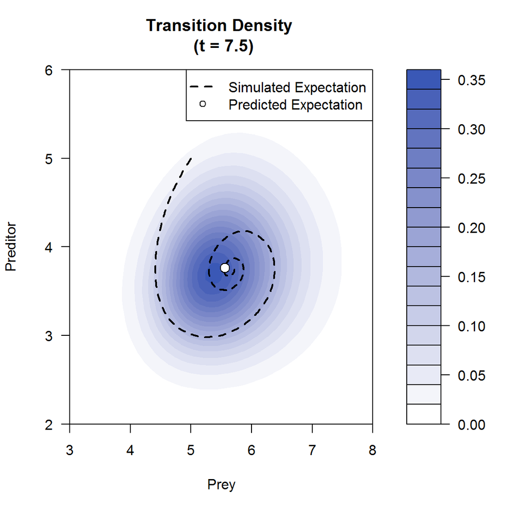

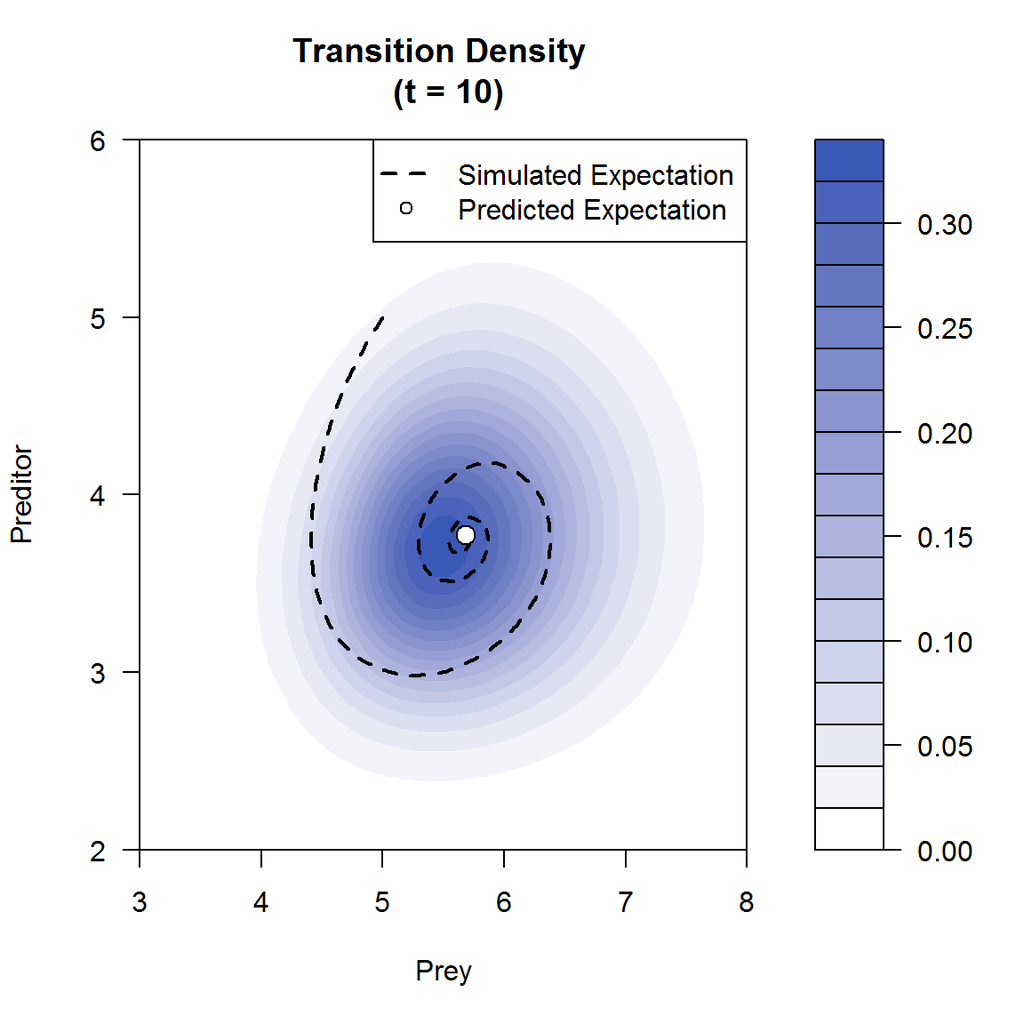

```r
# Load simulated trajectory of the joint expectation:
data(SDEsim3)
attach(SDEsim3)
# Record graphs at time points along the trajectory:
time.index <- c(10, 200, 750, 1000) + 1
# Make some colour palettes
library("colorspace")
colpal=function(n){rev(sequential_hcl(n, power = 1, l = c(40, 100)))}
for(i in time.index)
{
# Now illustrate the density using a contour plot:
filled.contour(res$Xt, res$Yt, res$density[,,i],
main=paste0('Transition Density \n (t = ',res$time[i],')'),
color.palette = colpal,
xlab = 'Prey', ylab = 'Preditor', plot.axes=
{
# Add trajectory of simulated expectation:
lines(my~mx, col = 'black', lty = 'dashed', lwd = 2)
# Show the predicted expectation from BiGQD.density():
points(res$cumulants[5,i]~res$cumulants[1,i],bg = 'white',pch = 21,cex = 1.5)
axis(1);axis(2);
# Add a legend:
legend('topright',lty = c('dashed', NA),pch = c(NA, 21), lwd = c(2, NA),
legend = c('Simulated Expectation', 'Predicted Expectation'))
})
}
```

As illustrated, the predicted expectation of the stochastic Lotka-Volterra equations under the cumulant truncation procedure matches very closely the simulated mean trajectory. However, what the transition density demonstrates is that, in contrast to the deterministic nature of the standard Lotka-Volterra equations, the inclusion of the Brownian motion terms implies vastly different population dynamics: In the deterministic case the trajectories are predicted to move ever closer to an equilibrium point (attractor), whilst with the stochastic equations it is likely for either of the two populations to move far away from such an equilibrium point due to the presence of random fluctuations - even as the expected trajectory stabilizes. Thus, where the deterministic equations may predict both populations to survive with certainty, as is with the current parameter set, under the stochastic equations both extinction and explosion events are probable while on average the population coordinates will tend to some equilibrium position as time increases.

# Further reading

- Package paper and replication materials.
- [Package manual](https://cran.r-project.org/web/packages/DiffusionRgqd/DiffusionRgqd.pdf)
- More Vignettes:
  - Introduction
  - Transitional densities
  - Performing inference on diffusion processes
  - First passage time problems
  - Or use:

```r
browseVignettes('DiffusionRgqd')
```

# References

Cobb, Loren, Peter Koppstein, and Neng Hsin Chen. 1983. “Estimation and Moment Recursion Relations for Multimodal Distributions of the Exponential Family.” *Journal of the American Statistical Association* 78 (381). Taylor & Francis: 124–30.

Cox, John C, Jonathan E Ingersoll Jr, and Stephen A Ross. 1985. “A Theory of the Term Structure of Interest Rates.” *Econometrica: Journal of the Econometric Society*. JSTOR, 385–407.

Gouriéroux, Christian, and Pascale Valéry. 2004. “Estimation of a Jacobi Process.” *Preprint*. Citeseer, 116.

Varughese, Melvin M. 2013. “Parameter Estimation for Multivariate Diffusion Systems.” *Computational Statistics & Data Analysis* 57 (1). Elsevier: 417–28.